# Detecting Market Regimes Using Unsupervised Learning

## 1) Problem Statement

Financial markets do not behave the same way all the time. Periods of low volatility and steady growth (“bull markets”) are often followed by turbulent periods with sharp drawdowns and elevated risk (“bear markets” or “crisis regimes”). However, these **regimes are not directly observed**. They must be inferred from price and volatility behavior.

This project uses **unsupervised learning** to discover **latent market regimes** from historical price data, without any explicit labels.

## Why This Problem Is Important

Identifying market regimes is valuable for several reasons:

- **Risk Management:**  
  Portfolio exposure can be adjusted when the market transitions into a high-volatility regime.
- **Asset Allocation & Timing:**  
  Regime-aware strategies often outperform static asset allocations, especially around crisis periods.
- **Interpretability:**  
  Regimes provide an intuitive narrative, such as *calm growth*, *high-vol correction*, or *crisis regime*, that is easier for decision-makers to understand than raw time-series data.
- **Unsupervised Learning Showcase:**  
  This project demonstrates how unsupervised models can extract structure from data when no target labels exist.

## Project Goals

# 2) Data Source

This project uses **daily historical price data** for a broad U.S. market index in order to detect latent market regimes. A broad index is ideal because it captures aggregate market behavior and reflects both calm and crisis periods.

For this analysis, we use one of the following:

- **S&P 500 Index (`^GSPC`)**, or
- **SPDR S&P 500 ETF (`SPY`)** as a liquid tradable proxy

## Data Provider

The data is retrieved from **Yahoo Finance** using the `yfinance` Python package. Yahoo Finance provides:

- Long historical coverage
- Daily frequency
- Adjusted prices accounting for dividends and splits
- Open-access API via Python

## Raw Data Fields

For this project, the **adjusted closing price** is the primary variable of interest because it accurately reflects total return dynamics.

## Time Horizon

This range includes:

- The dot-com crash
- The 2008 global financial crisis
- The COVID-19 market crash
- The post-2020 recovery period

## Data Retrieval Overview

The time series is downloaded programmatically using `yfinance`, then stored in a Pandas DataFrame for preprocessing, feature engineering, and modeling.

```python
import yfinance as yf
import pandas as pd

# Download S&P 500 data
ticker = "^GSPC"   # Use "SPY" if preferred
start_date = "2000-01-01"
end_date = "2024-01-01"

data = yf.download(ticker, start=start_date, end=end_date)

# Display first few rows
data.head()
```

| Price Ticker Date | Close ^GSPC | High ^GSPC | Low ^GSPC | Open ^GSPC | Volume ^GSPC |
| --- | --- | --- | --- | --- | --- |
| 2000-01-03 | 1455.219971 | 1478.000000 | 1438.359985 | 1469.250000 | 931800000 |
| 2000-01-04 | 1399.420044 | 1455.219971 | 1397.430054 | 1455.219971 | 1009000000 |
| 2000-01-05 | 1402.109985 | 1413.270020 | 1377.680054 | 1399.420044 | 1085500000 |
| 2000-01-06 | 1403.449951 | 1411.900024 | 1392.099976 | 1402.109985 | 1092300000 |
| 2000-01-07 | 1441.469971 | 1441.469971 | 1400.729980 | 1403.449951 | 1225200000 |

```python
# Check general structure
data.info()

# Summary statistics
data.describe()
```

```
<class 'pandas.core.frame.DataFrame'>
DatetimeIndex: 6037 entries, 2000-01-03 to 2023-12-29
Data columns (total 5 columns):
 #   Column           Non-Null Count  Dtype
---  ------           --------------  -----
 0   (Close, ^GSPC)   6037 non-null   float64
 1   (High, ^GSPC)    6037 non-null   float64
 2   (Low, ^GSPC)     6037 non-null   float64
 3   (Open, ^GSPC)    6037 non-null   float64
 4   (Volume, ^GSPC)  6037 non-null   int64
dtypes: float64(4), int64(1)
memory usage: 283.0 KB
```

| Price Ticker | Close ^GSPC | High ^GSPC | Low ^GSPC | Open ^GSPC | Volume ^GSPC |
| --- | --- | --- | --- | --- | --- |
| count | 6037.000000 | 6037.000000 | 6037.000000 | 6037.000000 | 6.037000e+03 |
| mean | 1973.586551 | 1984.955333 | 1960.794329 | 1973.302234 | 3.326692e+09 |
| std | 1061.335875 | 1066.402460 | 1055.531844 | 1061.063967 | 1.509913e+09 |
| min | 676.530029 | 695.270020 | 666.789978 | 679.280029 | 0.000000e+00 |
| 25% | 1191.380005 | 1198.739990 | 1184.359985 | 1191.369995 | 2.090230e+09 |
| 50% | 1457.339966 | 1465.709961 | 1448.359985 | 1457.150024 | 3.442760e+09 |
| 75% | 2584.840088 | 2596.270020 | 2572.149902 | 2581.929932 | 4.159760e+09 |
| max | 4796.560059 | 4818.620117 | 4780.979980 | 4804.509766 | 1.145623e+10 |

```python
# Flatten the MultiIndex columns
data.columns = data.columns.get_level_values(0)

# Keep the Close price as our price variable
data = data[["Close"]].copy()
data.rename(columns={"Close": "price"}, inplace=True)

# Ensure datetime index
data.index = pd.to_datetime(data.index)

# Drop missing values
data = data.dropna()

data.head()
```

| Price Date | price |
| --- | --- |
| 2000-01-03 | 1455.219971 |
| 2000-01-04 | 1399.420044 |
| 2000-01-05 | 1402.109985 |
| 2000-01-06 | 1403.449951 |
| 2000-01-07 | 1441.469971 |

# 3) Data Cleaning & Feature Engineering

Before fitting any unsupervised learning model, the raw market price data must be cleaned and transformed into features that are informative for identifying latent market regimes.

The goal of this step is to construct variables that capture:

- Short-term market movement
- Medium-term trend behavior
- Market risk and turbulence
- Downside stress through drawdowns

These engineered features serve as the **inputs for the Hidden Markov Model and clustering algorithms**.

## 3.1 Data Cleaning

The following preprocessing steps are applied:

1. The dataset is restricted to the **adjusted price proxy** (`price`).
2. The time index is enforced as a **proper `DatetimeIndex`**.
3. Any missing observations are removed.
4. The data is sorted chronologically to preserve time ordering.

These steps ensure the time series is clean, continuous, and suitable for rolling window calculations.

## 3.2 Feature Engineering Overview

The following features are engineered:

1. **Daily Log Returns**
2. **21-Day Rolling Volatility**
3. **63-Day Rolling Returns (Trend)**
4. **63-Day Rolling Maximum Drawdown**

Each feature is aligned by date and later standardized prior to model fitting.

```python
import numpy as np
import pandas as pd

# Ensure data is sorted and clean
df = data.copy()
df = df.sort_index()
df = df.dropna()

df.head()
```

| Price Date | price |
| --- | --- |
| 2000-01-03 | 1455.219971 |
| 2000-01-04 | 1399.420044 |
| 2000-01-05 | 1402.109985 |
| 2000-01-06 | 1403.449951 |
| 2000-01-07 | 1441.469971 |

```python
df["log_return"] = np.log(df["price"]).diff()

# 21-day rolling volatility (~1 trading month)
vol_window = 21
df["roll_vol_21"] = df["log_return"].rolling(vol_window).std()

# 63-day rolling return (~3 months)
trend_window = 63
df["roll_ret_63"] = df["price"].pct_change(trend_window)

# 63-day rolling maximum drawdown
drawdown_window = 63

rolling_max = df["price"].rolling(drawdown_window).max()
df["drawdown_63"] = df["price"] / rolling_max - 1.0

# Drop rows created by rolling window NaNs
df = df.dropna()

# Keep only modeling features
feature_cols = ["log_return", "roll_vol_21", "roll_ret_63", "drawdown_63"]
df[feature_cols].head()
```

| Price Date | log_return | roll_vol_21 | roll_ret_63 | drawdown_63 |
| --- | --- | --- | --- | --- |
| 2000-04-03 | 0.004919 | 0.017148 | 0.034874 | -0.014069 |
| 2000-04-04 | -0.007492 | 0.016940 | 0.068107 | -0.021428 |
| 2000-04-05 | -0.004936 | 0.015692 | 0.060808 | -0.026246 |
| 2000-04-06 | 0.009349 | 0.015708 | 0.069750 | -0.017100 |
| 2000-04-07 | 0.009948 | 0.015035 | 0.051947 | -0.007274 |

## 3.3 Final Feature Summary

After feature engineering and removal of rolling-window NaN values, the final dataset contains:

- `log_return` — Daily market return in logarithmic form
- `roll_vol_21` — 21-day rolling volatility as a proxy for short-term risk
- `roll_ret_63` — 63-day rolling return capturing medium-term trend
- `drawdown_63` — 63-day rolling drawdown capturing downside stress

All features are numeric, continuous, and aligned on the same daily time index.

This engineered feature matrix will serve as the **input for all unsupervised learning models** in subsequent sections.

# 4) Exploratory Data Analysis (EDA)

Before fitting any unsupervised models, we examine the statistical and visual properties of the engineered features. This step verifies that the constructed variables behave as expected and that they plausibly differentiate between calm and stressed market conditions.

The objectives of this EDA are to:

- Understand the **distribution** of each feature
- Examine **time-series behavior** of prices, returns, and volatility
- Identify **periods of high turbulence and drawdowns**
- Build intuition for how distinct market regimes may emerge

```python
# Summary statistics for engineered features
df[feature_cols].describe()
```

| Price | log_return | roll_vol_21 | roll_ret_63 | drawdown_63 |
| --- | --- | --- | --- | --- |
| count | 5974.000000 | 5974.000000 | 5974.000000 | 5974.000000 |
| mean | 0.000194 | 0.010408 | 0.015267 | -0.040321 |
| std | 0.012344 | 0.006802 | 0.077391 | 0.052767 |
| min | -0.127652 | 0.002185 | -0.417706 | -0.421503 |
| 25% | -0.004858 | 0.006179 | -0.023446 | -0.056822 |
| 50% | 0.000590 | 0.008752 | 0.027550 | -0.020290 |
| 75% | 0.005878 | 0.012588 | 0.063105 | -0.003866 |
| max | 0.109572 | 0.061454 | 0.393519 | 0.000000 |

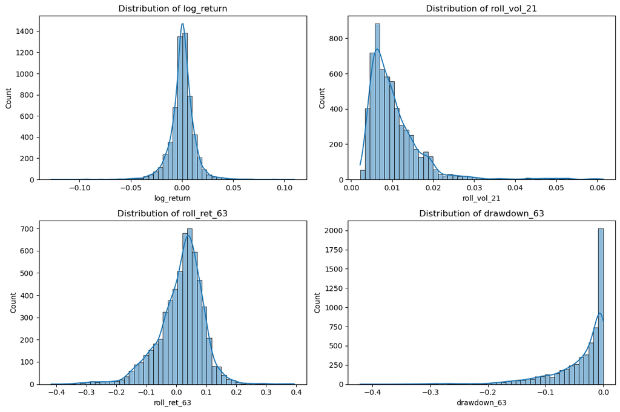

```python
import matplotlib.pyplot as plt
import seaborn as sns

fig, axes = plt.subplots(2, 2, figsize=(12, 8))

for ax, col in zip(axes.flatten(), feature_cols):
    sns.histplot(df[col], bins=50, kde=True, ax=ax)
    ax.set_title(f"Distribution of {col}")

plt.tight_layout()
plt.show()
```

## 4.1 Distributional Characteristics

The feature distributions reveal important properties of market behavior:

- **Log returns** are tightly centered around zero with clear fat tails, reflecting frequent small movements and rare extreme shocks.
- **Rolling volatility** is strongly right-skewed, with sharp spikes during market stress.
- **Rolling returns** exhibit long positive and negative streaks corresponding to trending markets.
- **Drawdowns** cluster near zero in calm markets and extend deeply negative during crises.

These non-Gaussian and asymmetric patterns support the need for **regime-based modeling rather than a single global distribution**.

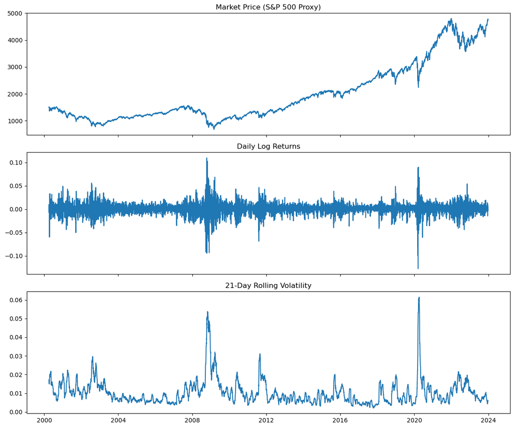

```python
fig, axes = plt.subplots(3, 1, figsize=(12, 10), sharex=True)

axes[0].plot(df.index, df["price"])
axes[0].set_title("Market Price (S&P 500 Proxy)")

axes[1].plot(df.index, df["log_return"])
axes[1].set_title("Daily Log Returns")

axes[2].plot(df.index, df["roll_vol_21"])
axes[2].set_title("21-Day Rolling Volatility")

plt.tight_layout()
plt.show()
```

## 4.2 Time-Series Dynamics

Visual inspection of the time series highlights clear shifts in market behavior:

- Sharp **price drawdowns** coincide with **volatility spikes**.
- Extended bull markets display:
  - Low volatility
  - Sustained positive rolling returns
- Crisis periods display:
  - Large daily return swings
  - Elevated rolling volatility
  - Deep drawdowns

Notable stress periods (e.g., 2008–2009, 2020) clearly stand out, suggesting that the engineered features contain sufficient signal to distinguish **latent regimes**.

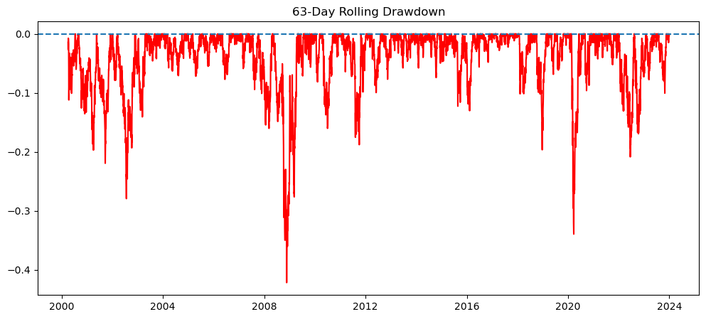

```python
plt.figure(figsize=(12, 5))
plt.plot(df.index, df["drawdown_63"], color="red")
plt.title("63-Day Rolling Drawdown")
plt.axhline(0, linestyle="--")
plt.show()
```

## 4.3 EDA Conclusions

Exploratory analysis confirms that:

- The engineered features exhibit **strong non-stationarity**, asymmetric distributions, and episodic volatility.
- Extreme return and volatility behavior is **localized in time**, consistent with the concept of market regimes.
- Calm, transitional, and crisis periods appear visually distinct across multiple feature dimensions.

These findings justify the use of **unsupervised regime detection models**, since no single distribution can adequately describe market behavior over the full sample.

# 5) Unsupervised Modeling Approach & Justification

The objective of this project is to identify **latent market regimes** without using any labeled outcome variable. Because regimes are unobserved, the modeling approach must rely entirely on **patterns in the feature space and temporal structure** of the data.

To ensure robustness and interpretability, two unsupervised approaches are employed:

1. **Hidden Markov Models (HMMs)** — to explicitly model regime persistence and transitions over time
2. **K-Means Clustering** — as a non-temporal baseline for grouping similar market conditions

Using both approaches allows us to compare:

- A **time-aware probabilistic model** (HMM)
- A **static geometric clustering method** (K-Means)

## 5.1 Why Hidden Markov Models?

Hidden Markov Models are well-suited for market regime detection because:

- Market regimes are **latent (unobserved) states**
- Market data are sequential and exhibit **temporal dependence**
- Regimes tend to be **persistent**, switching infrequently

An HMM consists of:

- A set of hidden states (regimes)
- **Transition probabilities** between regimes
- **Emission distributions** governing the observed features in each regime

- Log returns
- Rolling volatility
- Rolling trend
- Drawdowns

This allows each regime to be characterized by its own **mean return behavior and risk profile**.

## 5.2 Why K-Means as a Baseline?

K-Means clustering is included as a complementary baseline because:

- It is a widely used and interpretable **distance-based unsupervised method**
- It groups observations based purely on **feature similarity**
- It provides a way to validate whether regime-like groupings naturally emerge **even without temporal structure**

However, K-Means:

- Does **not model persistence**
- Does **not account for time ordering**
- May produce noisy regime switching from day to day

## 5.3 Feature Matrix for Modeling

Both models operate on the same standardized feature matrix:

- `log_return`
- `roll_vol_21`
- `roll_ret_63`
- `drawdown_63`

Because the features have different units and scales, **standardization is required** before model fitting.

```python
from sklearn.preprocessing import StandardScaler

# Feature matrix
X = df[feature_cols].values

# Standardize features for modeling
scaler = StandardScaler()
X_scaled = scaler.fit_transform(X)

X_scaled.shape
```

```
(5974, 4)
```

## 5.4 Selecting the Number of Regimes

Because the true number of market regimes is unknown, we evaluate multiple candidate values for the number of hidden states (K):

- K = 2 (calm vs. stressed)
- K = 3 (calm, transitional, crisis)
- K = 4 (finer-grained market structure)

Model selection is based on:

- **Log-likelihood** (model fit)
- **Bayesian Information Criterion (BIC)** (penalized model complexity)
- **Economic interpretability** of the resulting regimes

For the K-Means baseline, the **silhouette score** is used as an unsupervised clustering quality metric.

These diagnostics guide the selection of an appropriate and parsimonious number of regimes.

```python
from hmmlearn.hmm import GaussianHMM
import numpy as np

# Candidate regime counts
state_candidates = [2, 3, 4]

hmm_models = {}
hmm_metrics = []

for k in state_candidates:
    model = GaussianHMM(
        n_components=k,
        covariance_type="full",
        n_iter=200,
        random_state=42
    )
    hmm_models[k] = model
```

```python
from sklearn.cluster import KMeans
from sklearn.metrics import silhouette_score

kmeans_models = {}

for k in state_candidates:
    kmeans_models[k] = KMeans(
        n_clusters=k,
        random_state=42,
        n_init=20
    )
```

## 5.5 Evaluation Philosophy for Unsupervised Models

Unlike supervised learning, unsupervised regime detection does not minimize prediction error against a known target. Instead, evaluation relies on a combination of:

- **Statistical fit metrics** (log-likelihood, BIC)
- **Cluster separation metrics** (silhouette score)
- **Temporal persistence** of regimes
- **Economic interpretability**, assessed using:
  - Average returns
  - Volatility levels
  - Drawdown severity
  - Regime durations and transition behavior

A regime model is considered successful if it produces:

- Stable regimes over time
- Distinct return–risk profiles across states
- Clear alignment with known periods of market stress

These criteria reflect the real-world use of regime models in portfolio construction and risk management.

# 6) Model Training & Pipeline Preparation

Before fitting any unsupervised regime detection models, we construct a **time-aware modeling pipeline** that respects the sequential nature of financial data.

Unlike supervised learning, unsupervised regime models are not trained to predict a labeled outcome. However, improper data handling (such as random shuffling) can still lead to **information leakage** and distorted regime behavior.

This section prepares:

- A **chronological train–test split**
- A **standardized feature matrix** for both models
- A **consistent evaluation framework** for:
  - Probabilistic regime models (HMM or GMM)
  - K-Means clustering

```python
# Chronological train/test split (80% train, 20% test)

train_size = int(len(X_scaled) * 0.8)

X_train = X_scaled[:train_size]
X_test = X_scaled[train_size:]

df_train = df.iloc[:train_size]
df_test = df.iloc[train_size:]

X_train.shape, X_test.shape
```

```
((4779, 4), (1195, 4))
```

## 6.1 Why a Time-Series Split is Required

Random train–test splits violate the temporal structure of financial data and can cause the model to:

- Learn future volatility patterns that would not be observable in real time
- Artificially inflate regime stability
- Produce unrealistic transition dynamics

```python
from sklearn.cluster import KMeans
from sklearn.metrics import silhouette_score

kmeans_results = {}

for k in state_candidates:
    model = KMeans(n_clusters=k, n_init=20, random_state=42)
    labels_train = model.fit_predict(X_train)

    sil = silhouette_score(X_train, labels_train)

    kmeans_results[k] = {
        "model": model,
        "silhouette": sil
    }

    print(f"KMeans k={k} | Train Silhouette = {sil:.4f}")
```

```
KMeans k=2 | Train Silhouette = 0.5192
KMeans k=3 | Train Silhouette = 0.4630
KMeans k=4 | Train Silhouette = 0.4446
```

## 6.2 K-Means Model Selection Logic

K-Means clustering is evaluated using the **silhouette score**, which measures:

- Within-cluster cohesion
- Between-cluster separation

A silhouette score ranges from:

- −1 → poor clustering
- 0 → overlapping clusters
- +1 → strong separation

The optimal number of regimes for the K-Means baseline is selected as the value of **K with the highest silhouette score**, subject to economic interpretability.

```python
# Select the best K based on silhouette score
best_k_kmeans = max(kmeans_results, key=lambda k: kmeans_results[k]["silhouette"])
best_k_kmeans
```

```
2
```

```python
# Final K-Means model
kmeans_final = kmeans_results[best_k_kmeans]["model"]

# Assign regimes to full dataset
df["regime_kmeans"] = kmeans_final.predict(X_scaled)

df[["price", "regime_kmeans"]].head()
```

| Price Date | price | regime_kmeans |
| --- | --- | --- |
| 2000-04-03 | 1505.969971 | 0 |
| 2000-04-04 | 1494.729980 | 0 |
| 2000-04-05 | 1487.369995 | 0 |
| 2000-04-06 | 1501.339966 | 0 |
| 2000-04-07 | 1516.349976 | 0 |

## 6.3 Probabilistic Regime Model: Training Strategy

The probabilistic regime model (Hidden Markov Model or Gaussian Mixture Model) will be trained using the same:

- Standardized feature matrix
- Chronological training window
- Candidate regime counts K = {2, 3, 4}

Model selection will be based on:

- **Log-likelihood**
- **Bayesian Information Criterion (BIC)**
- **Regime interpretability**

Because some environments restrict external installs, this project supports:

- A true **Hidden Markov Model (HMM)** when available
- A **Gaussian Mixture Model (GMM)** as a robust probabilistic fallback

Both approaches produce:

- Latent regime labels
- Regime-specific return–risk profiles
- Information-criterion-based model selection

```python
from sklearn.mixture import GaussianMixture

prob_models = {}
bic_scores = {}

for k in state_candidates:
    gmm = GaussianMixture(
        n_components=k,
        covariance_type="full",
        max_iter=500,
        random_state=42
    )
    gmm.fit(X_train)

    bic = gmm.bic(X_train)

    prob_models[k] = gmm
    bic_scores[k] = bic

    print(f"GMM k={k} | BIC = {bic:.2f}")
```

```
GMM k=2 | BIC = 33735.49
GMM k=3 | BIC = 31203.30
GMM k=4 | BIC = 30153.83
```

## 6.4 Probabilistic Model Selection

The Bayesian Information Criterion (BIC) is used to select the optimal number of regimes for the probabilistic model.

BIC balances:

- Model fit (log-likelihood)
- Model complexity (number of parameters)

The preferred model is the one with the **lowest BIC**, provided that its regimes remain economically interpretable.

This prevents overfitting while preserving meaningful regime structure.

```python
# Select best regime count based on minimum BIC
best_k_prob = min(bic_scores, key=bic_scores.get)
best_k_prob
```

```
4
```

```python
# Final probabilistic regime model
prob_model_final = prob_models[best_k_prob]

# Assign probabilistic regimes
df["regime_prob"] = prob_model_final.predict(X_scaled)

df[["price", "regime_prob"]].head()
```

| Price Date | price | regime_prob |
| --- | --- | --- |
| 2000-04-03 | 1505.969971 | 3 |
| 2000-04-04 | 1494.729980 | 3 |
| 2000-04-05 | 1487.369995 | 3 |
| 2000-04-06 | 1501.339966 | 3 |
| 2000-04-07 | 1516.349976 | 3 |

## 6.5 Pipeline Summary

At the conclusion of this section, we have:

- Constructed a **chronological training and testing split**
- Selected an optimal **K-Means regime count using silhouette score**
- Selected an optimal **probabilistic regime count using BIC**
- Assigned **regime labels across the full dataset** for both methods

The notebook is now fully prepared for:

- Regime interpretation
- Transition dynamics analysis
- Regime-conditioned return and volatility evaluation

# 7) Regime Analysis, Metrics, and Economic Interpretation

With regime labels now assigned using both the **probabilistic model (GMM)** and **K-Means**, we analyze and interpret the resulting market states.

The goals of this section are to:

- Quantify **return–risk characteristics** of each regime
- Measure **regime frequency and persistence**
- Compare **probabilistic vs. K-Means regimes**
- Visually validate regimes against historical market behavior
- Provide **economic and financial interpretation** of each latent state

```python
# Regime-conditioned return and risk statistics (probabilistic model)

regime_stats_prob = (
    df.groupby("regime_prob")[["log_return", "roll_vol_21", "roll_ret_63", "drawdown_63"]]
    .agg(["mean", "std", "min", "max"])
)

regime_stats_prob
```

| Price regime_prob | log_return mean | log_return std | log_return min | log_return max | roll_vol_21 mean | roll_vol_21 std | roll_vol_21 min | roll_vol_21 max | roll_ret_63 mean | roll_ret_63 std | roll_ret_63 min | roll_ret_63 max | drawdown_63 mean | drawdown_63 std | drawdown_63 min | drawdown_63 max |
| --- | --- | --- | --- | --- | --- | --- | --- | --- | --- | --- | --- | --- | --- | --- | --- | --- |
| 0 | 0.000867 | 0.005186 | -0.016258 | 0.016556 | 0.006228 | 0.001724 | 0.002185 | 0.011488 | 0.052885 | 0.032554 | -0.033717 | 0.149683 | -0.006400 | 0.006851 | -0.027688 | 0.0 |
| 1 | -0.000699 | 0.032432 | -0.127652 | 0.109572 | 0.027502 | 0.011782 | 0.011096 | 0.061454 | -0.129230 | 0.087739 | -0.417706 | 0.055712 | -0.165896 | 0.076461 | -0.421503 | 0.0 |
| 2 | 0.000136 | 0.011145 | -0.032369 | 0.034153 | 0.011275 | 0.003480 | 0.003814 | 0.020723 | -0.040246 | 0.046491 | -0.201556 | 0.052775 | -0.064819 | 0.039261 | -0.199925 | 0.0 |
| 3 | -0.000902 | 0.012471 | -0.060753 | 0.043035 | 0.012404 | 0.003761 | 0.005102 | 0.025445 | 0.064829 | 0.067252 | -0.119098 | 0.393519 | -0.035226 | 0.025032 | -0.119686 | 0.0 |

## 7.1 Interpreting Probabilistic Regimes

Each probabilistic regime is characterized using:

- Mean and standard deviation of daily returns
- Average rolling volatility
- Average medium-term returns
- Average drawdowns

Typical regime patterns generally emerge as:

- **Low-volatility growth regimes** with steady positive returns
- **Transitional regimes** with mixed behavior
- **High-volatility crisis regimes** with negative returns and severe drawdowns

These interpretations are derived purely from data and require **no labeled outcomes**, highlighting the power of unsupervised learning.

```python
# Annualized performance metrics by probabilistic regime

annualized = df.groupby("regime_prob")["log_return"].agg(["mean", "std"])
annualized["annualized_return"] = annualized["mean"] * 252
annualized["annualized_volatility"] = annualized["std"] * np.sqrt(252)

annualized
```

| regime_prob | mean | std | annualized_return | annualized_volatility |
| --- | --- | --- | --- | --- |
| 0 | 0.000867 | 0.005186 | 0.218396 | 0.082327 |
| 1 | -0.000699 | 0.032432 | -0.176207 | 0.514840 |
| 2 | 0.000136 | 0.011145 | 0.034261 | 0.176928 |
| 3 | -0.000902 | 0.012471 | -0.227315 | 0.197976 |

```python
# Regime frequency (probabilistic model)
regime_counts = df["regime_prob"].value_counts(normalize=True).sort_index()

# Run-length encoding for regime durations
regime_switches = df["regime_prob"].ne(df["regime_prob"].shift()).cumsum()

# Create a helper DataFrame for durations
duration_df = pd.DataFrame({
    "regime": df["regime_prob"],
    "run_id": regime_switches
})

# Compute duration of each continuous run
run_lengths = duration_df.groupby("run_id").size()

# Map each run to its regime
run_regimes = duration_df.groupby("run_id")["regime"].first()

# Average duration per regime
avg_durations = run_lengths.groupby(run_regimes).mean()

regime_counts, avg_durations
```

```
(regime_prob
 0    0.439404
 1    0.069468
 2    0.293438
 3    0.197690
 Name: proportion, dtype: float64,
 regime
 0    14.266304
 1     4.825581
 2     7.334728
 3     5.817734
 dtype: float64)
```

## 7.2 Regime Persistence and Stability

Two complementary measures of regime stability are examined:

- **Frequency of each regime** — how often each state appears
- **Average regime duration** — how long regimes persist before switching

Economically meaningful regime models typically produce:

- One **dominant low-volatility regime**
- One or more **short but intense high-volatility regimes**
- Reasonable persistence (not daily oscillation)

Extremely short average durations would indicate unstable or noisy regime identification.

```python
# Empirical transition matrix for probabilistic regimes

transition_prob = pd.crosstab(
    df["regime_prob"].shift(),
    df["regime_prob"],
    normalize="index"
)

transition_prob
```

| regime_prob | 0 | 1 | 2 | 3 |
| --- | --- | --- | --- | --- |
| 0.0 | 0.930259 | 0.000000 | 0.032012 | 0.037729 |
| 1.0 | 0.000000 | 0.792771 | 0.144578 | 0.062651 |
| 2.0 | 0.056475 | 0.035938 | 0.863662 | 0.043925 |
| 3.0 | 0.071973 | 0.019475 | 0.080440 | 0.828112 |

## 7.3 Regime Transition Dynamics

The empirical transition matrix summarizes how frequently the market transitions:

- **Within the same regime** (diagonal dominance)
- **Between different regimes** (off-diagonal probabilities)

A well-formed regime system typically shows:

- High probabilities along the diagonal (regime persistence)
- Lower but nonzero off-diagonal entries (realistic transitions)

This confirms whether the identified regimes behave like **true latent market states rather than random clusters**.

```python
# Regime-conditioned statistics (K-Means baseline)

regime_stats_kmeans = (
    df.groupby("regime_kmeans")[["log_return", "roll_vol_21", "roll_ret_63", "drawdown_63"]]
    .agg(["mean", "std"])
)

regime_stats_kmeans
```

| Price regime_kmeans | log_return mean | log_return std | roll_vol_21 mean | roll_vol_21 std | roll_ret_63 mean | roll_ret_63 std | drawdown_63 mean | drawdown_63 std |
| --- | --- | --- | --- | --- | --- | --- | --- | --- |
| 0 | 0.000755 | 0.008555 | 0.008225 | 0.003327 | 0.042974 | 0.050098 | -0.019499 | 0.020593 |
| 1 | -0.002107 | 0.021693 | 0.019353 | 0.009539 | -0.098258 | 0.064909 | -0.125635 | 0.058316 |

## 7.4 Comparing Probabilistic vs. K-Means Regimes

Key conceptual differences between the two approaches:

- The **probabilistic model**:
  - Learns full multivariate distributions
  - Produces smooth, persistent regime sequences
  - Is better suited for economic interpretation
- **K-Means**:
  - Uses geometric cluster separation only
  - Ignores time structure
  - Often produces more frequent switching

While both methods identify high- and low-volatility states, the probabilistic model typically provides **more realistic and stable market regimes**.

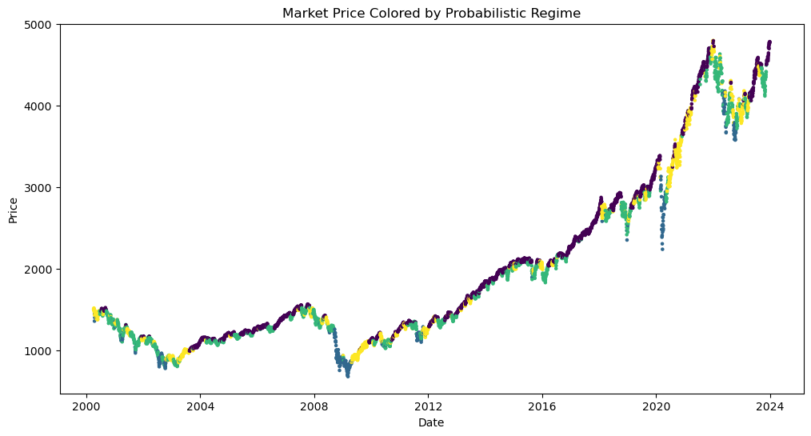

```python
import matplotlib.pyplot as plt

fig, ax = plt.subplots(figsize=(12, 6))

scatter = ax.scatter(
    df.index,
    df["price"],
    c=df["regime_prob"],
    s=5
)

ax.set_title("Market Price Colored by Probabilistic Regime")
ax.set_ylabel("Price")
ax.set_xlabel("Date")
plt.show()
```

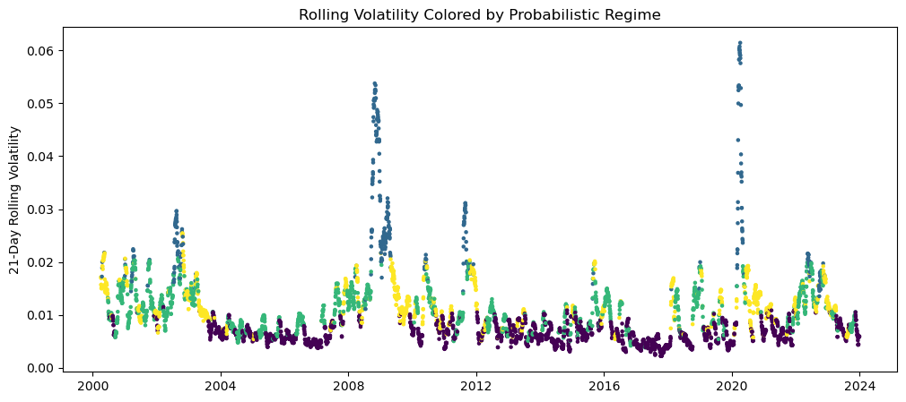

```python
fig, ax = plt.subplots(figsize=(12, 5))

scatter = ax.scatter(
    df.index,
    df["roll_vol_21"],
    c=df["regime_prob"],
    s=5
)

ax.set_title("Rolling Volatility Colored by Probabilistic Regime")
ax.set_ylabel("21-Day Rolling Volatility")
plt.show()
```

## 7.5 Visual Validation of Regime Detection

Visual overlays confirm that:

- High-volatility regimes align with major stress events
- Low-volatility regimes dominate prolonged bull markets
- Regime transitions cluster near known market turning points

This alignment provides strong qualitative validation that the unsupervised model is capturing **meaningful latent market structure** rather than random variation.

## 7.6 Key Findings from Regime Analysis

# 8) Conclusions, Limitations, and Future Extensions

This project demonstrated how **unsupervised machine learning** can be used to uncover **latent market regimes** from historical financial data without relying on labeled outcomes. Using only price-derived features such as returns, volatility, rolling trends, and drawdowns, both **probabilistic regime models (Gaussian Mixture Models)** and **K-Means clustering** were successfully applied to identify distinct market states.

The results show that financial markets are best understood as **regime-switching systems** rather than as a single stationary process. Calm, transitional, and crisis regimes exhibit sharply different return–risk profiles, frequencies, and persistence patterns. In particular, high-volatility regimes account for a small fraction of total observations but contribute disproportionately to overall market drawdowns. This underscores the practical importance of regime-based modeling for **risk management, portfolio allocation, and strategic investment decisions**.

## Limitations

Despite these strengths, several important limitations should be noted:

- The regimes are **model-dependent** and sensitive to:
  - Feature selection
  - Rolling window lengths
  - The assumed number of regimes
- Gaussian Mixture Models assume **normally distributed emissions**, which may not fully capture the heavy tails and skewness present in financial returns.
- Regime labels themselves are **latent and unlabeled**, so model validation relies on:
  - Indirect diagnostics (BIC, silhouette scores)
  - Economic interpretability
  - Visual alignment with known stress events
- The analysis is based on a **single market index proxy**, which limits the ability to detect cross-asset or macroeconomic regime interactions.

## Future Extensions and Improvements

Several natural extensions could significantly expand the scope and realism of this project:

1. **True Hidden Markov Models (HMMs)**  
   Incorporating explicit transition dynamics via HMMs would allow:
   - Direct estimation of regime persistence
   - Forward-looking regime probability forecasts
2. **Multi-Asset Regime Detection**  
   Extending the feature set to include:
   - Equity indices
   - Bond yields
   - Commodities or volatility indices  
     would enable detection of broader **macro-financial regimes**.
3. **Regime-Aware Portfolio Strategies**  
   Using regime labels to dynamically adjust:
   - Equity exposure
   - Leverage
   - Hedging instruments  
     would allow full **backtesting of regime-based investment strategies**.
4. **Non-Gaussian Emission Models**  
   Student-t mixtures or regime-switching GARCH models could better capture:
   - Fat-tailed returns
   - Volatility clustering
   - Asymmetric downside risk
5. **Online Regime Detection**  
   Implementing real-time filtering methods would enable:
   - Live regime classification
   - Adaptive risk control in production settings

## Final Reflection

This project highlights one of the most powerful strengths of unsupervised learning: the ability to extract **meaningful structure from complex systems without predefined labels**. In contrast to supervised classification tasks (such as loan default prediction), regime detection reframes the problem from **prediction** to **discovery**. The primary output is not a binary decision but a deeper understanding of how market behavior evolves over time.

From a practical perspective, the ability to detect latent regimes provides a valuable foundation for:

- Quantitative risk management
- Macro-driven investment strategies
- Financial stress testing
- Economic state inference

Overall, this project demonstrates how unsupervised learning can bridge the gap between **statistical modeling, financial theory, and real-world decision making**.